# HW 3 Solutions

Published

October 1, 2026

## Overview

### Load Environment

The following code loads the environment and makes sure all needed packages are installed. This should be at the start of most Julia scripts.

```julia
import Pkg
Pkg.activate(@__DIR__)
Pkg.instantiate()
```

```julia
using Plots
using LaTeXStrings
```

## Problems (Total: 50 Points)

### Problem 1 (15)

#### Problem 1.1 (4)

$$\frac{dC}{dt} = 5 - 0.25C$$

**(a)** Denoting the right-hand side $f(C) = 5 - 0.25C$, the forward Euler update is
$$C(t + \Delta t) = C(t) + \Delta t\left(5 - 0.25\,C(t)\right).$$

**(b)** This is a linear system with a single rate constant, so its characteristic timescale is
$$1/|-0.25| = 4$$
. Since $\Delta t = 1$ is four times smaller than the timescale, it is a reasonable starting choice, though it might not be small enough to account for discretization error.

**(c)** Assuming first-order convergence (as expected from the Taylor approximation underlying Forward Euler discretization), error scales linearly with $\Delta t$. So halving $\Delta t$ from 2 to 1 should halve the error:
$$\text{error}(\Delta t = 1) \approx 0.6 \times \frac{1}{2} = 0.3.$$

#### Problem 1.2 (5)

$$\frac{dC}{dt} = \frac{Q}{V}\left(C_\text{in} - C\right) - kC$$

**(a)** With $Q/V = 50/200 = 0.25\ \text{yr}^{-1}$, the forward Euler update is
$$\begin{aligned}
C(t + \Delta t) &= C(t) + \Delta t\left[\frac{Q}{V}\left(C_\text{in} - C(t)\right) - kC(t)\right] \\
&= C(t) + \Delta t\left[0.25\left(2 - C(t)\right) - 0.3\,C(t)\right] \\
&= C(t) + \Delta t\left(0.5 - 0.55 C(t)\right).
\end{aligned}$$

**(b)** $\frac{dC}{dt} = 0.5 - 0.55C$: the two loss terms combine into a single effective rate $-0.55\ \text{yr}^{-1}$. The characteristic timescale is $1/|-0.55| \approx 1.82\ \text{yr}$. $\Delta t = 1\ \text{yr}$ could be a reasonable starting choice, though as with Problem 1.1, there could still be discretization error that would need to be reduced by refining $\Delta t$.

**(c)** Here $\Delta t$ shrinks by a factor of 4 (from 1.6 to 0.4), so under first-order convergence the error should also shrink by a factor of 4:
$$\text{error}(\Delta t = 0.4) \approx 0.8 \times \frac{1}{4} = 0.2.$$

#### Problem 1.3 (6)

$$\frac{dx}{dt} = 3 - 0.5x^2, \qquad x \geq 0$$

**(a)** Denoting $f(x) = 3 - 0.5x^2$, the forward Euler update is
$$x(t + \Delta t) = x(t) + \Delta t\left(3 - 0.5\,x(t)^2\right).$$

**(b)** The equilibrium solves $3 - 0.5(x^*)^2 = 0 \implies x^* = \sqrt{6} \approx 2.449$ (taking the positive root, per the problem’s domain). $f'(x) = -x$, so $g = f'(x^*) = -\sqrt{6} \approx -2.449$. The local characteristic timescale there is $1/|\sqrt{6}| \approx 0.408$.

$\Delta t = 0.5$ is *larger* than this local timescale so this is not a reasonable starting value near this equilibrium.

**(c)** Here $\Delta t$ shrinks by a factor of 3, so
$$\text{error}(\Delta t = 0.1) \approx 1.5 \times \frac{1}{3} = 0.5.$$

### Problem 2 (35)

#### Problem 2.1 (5)

Denoting the right-hand sides $f(P,M) = L - s_\text{out}P - hP + \kappa M \frac{P^q}{m^q+P^q}$ and $g(P,M) = hP - bM - \kappa M \frac{P^q}{m^q+P^q}$, the coupled forward Euler update is

$$\begin{aligned}
P(t + \Delta t) &= P(t) + \Delta t\left[L - s_\text{out}P(t) - hP(t) + \kappa M(t)\,\frac{P(t)^q}{m^q + P(t)^q}\right] \\
M(t + \Delta t) &= M(t) + \Delta t\left[hP(t) - bM(t) - \kappa M(t)\,\frac{P(t)^q}{m^q + P(t)^q}\right]
\end{aligned}$$

Note: **both** updates must use the recycling term evaluated at the *current* $P(t)$ and $M(t)$. A common mistake is to update $P$ first and then use the *new* $P(t+\Delta t)$ when updating $M$ — this is not forward Euler (it’s closer to a Gauss-Seidel-style update), which requires joint linearization (recall the multivariate Taylor expansion we used to derive the condition for higher-dimensional stability). As a result, it does not have the same error properties we derived in class. You won’t lose points for this — we didn’t talk about it in class, but it’s good to be aware of.

#### Problem 2.2 (13)

**Choosing $T$.** The slow variable is the sediment pool $M$, whose timescale is $1/b = 1/0.02 = 50\ \text{yr}$. $T = 300\ \text{yr}$ is six of those — comfortably long enough for $M$ to fill.

**Choosing the quantity of interest.** $P(30)$, while the lake is still changing. The value at the *end* of the run would be useless here: by $t = 300$ the system has relaxed, and every stable step size returns the same number to six or more digits.

```julia
outflow_rate, sediment_transfer = 0.3, 0.3
burial_rate, recycling_coefficient = 0.02, 0.15
half_saturation, steepness = 25.0, 8.0

function recycling_flux(phosphorus, sediment)
    saturation = phosphorus^steepness /
                 (half_saturation^steepness + phosphorus^steepness)
    recycling_coefficient * sediment * saturation
end

function simulate_lake(loading, horizon, step)
    steps = Int(round(horizon / step))
    trajectory = zeros(steps)
    phosphorus, sediment = 0.0, 0.0
    for i in 1:steps
        recycled = recycling_flux(phosphorus, sediment)
        change_in_phosphorus = loading - outflow_rate*phosphorus -
                               sediment_transfer*phosphorus + recycled
        change_in_sediment = sediment_transfer*phosphorus -
                             burial_rate*sediment - recycled
        phosphorus += step * change_in_phosphorus
        sediment += step * change_in_sediment
        trajectory[i] = phosphorus
    end
    trajectory
end

phosphorus_at_30(step) = simulate_lake(10.0, 300.0, step)[Int(30 / step)]

step_reference = 0.001
reference_value = phosphorus_at_30(step_reference)

step_sizes = [2.0, 1.0, 0.5, 0.25, 0.125, 0.0625]
values = [phosphorus_at_30(step) for step in step_sizes]
errors = [abs(value - reference_value) for value in values]
orders = [log2(errors[i] / errors[i+1]) for i in 1:length(errors)-1]
```

Reference solution at $\Delta t = 0.001$ yr gives $P(30) =$ 18.58479 $\mu\text{g}/\text{L}$.

| $\Delta t$ [yr] | $P(30)$ | error | empirical order |
| --- | --- | --- | --- |
| 2.0000 | 18.6349 | 5.01e-02 | — |
| 1.0000 | 18.6092 | 2.44e-02 | 1.04 |
| 0.5000 | 18.5970 | 1.22e-02 | 1.00 |
| 0.2500 | 18.5909 | 6.09e-03 | 1.00 |
| 0.1250 | 18.5878 | 3.04e-03 | 1.00 |
| 0.0625 | 18.5863 | 1.51e-03 | 1.01 |

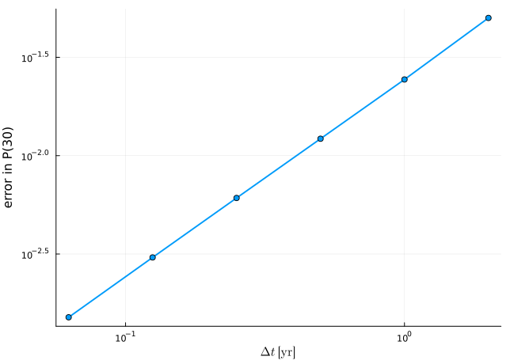

Figure 1: Error in P(30) against step size. The slope is the order of convergence.

The error is first order, as expected for forward Euler — and the errors span a factor of 33 from coarsest to finest. **$\Delta t = 0.125\ \text{yr}$** is used for the rest of this problem: the error there is 0.003 $\mu\text{g}/\text{L}$, far below anything that would change the interpretation in Problem 2.3, and the run is still fast.

**NoteThe horizon and the step size are set by different processes**

$T$ was chosen based on the *slowest* process in the system, the sediment pool at $1/b = 50\ \text{yr}$. $\Delta t$ is constrained by the *fastest*, which is $P$ itself at $1/(s_\text{out} + h) \approx 1.7\ \text{yr}$. A step chosen by looking only at $M$ would be wildly too large.

Steps well above the fast timescale do not merely lose accuracy — they can destabilise. At $\Delta t = 4\ \text{yr}$ this model blows up entirely. Note the transition is not a perfectly abrupt: $\Delta t = 3.5$ still returns a finite (but badly wrong) answer.

#### Problem 2.3 (10)

Simulating at $L = 10\ \mu\text{g}/(\text{L}\cdot\text{yr})$ with the step size chosen in Problem 2.2 gives the trajectory below.

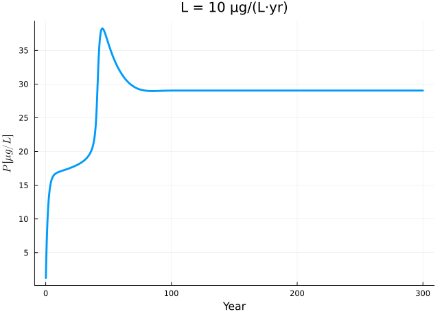

Figure 2: P(t) for the two-stock lake model at L = 10 μg/(L·yr).

From Problem 2.2, $P(30) =$ 18.6 $\mu\text{g}/\text{L}$ — a modest, plausibly-stable oligotrophic reading, a little above the naive one-stock estimate but not alarmingly so. Once the simulation has fully run, $P$ settles to a **much higher** equilibrium of about 29.0 $\mu\text{g}/\text{L}$ — solidly eutrophic, well above $m = 25$.

Physically: at $t = 30$, the sediment pool $M$ hasn’t yet accumulated enough phosphorus for recycling to matter much, so the lake behaves close to a simple outflow-dominated system. As $M$ slowly builds (over the sediment timescale, $1/b = 50\ \text{yr}$), the recycling term $\kappa M \cdot P^q/(m^q+P^q)$ becomes large enough to meaningfully add phosphorus back to the water column. This triggers a rapid transition — visible as a sharp rise and an overshoot, peaking around $P =$ 38.2 $\mu\text{g}/\text{L}$ near $t =$ 45 yr — before the system settles into its new, eutrophic equilibrium by roughly $t = 80$–$90\ \text{yr}$.

#### Problem 2.4 (7)

The naive one-stock model, $\frac{dP}{dt} = L - s_\text{out}P - hP$, has equilibrium
$$P^*_\text{naive} = \frac{L}{s_\text{out}+h} = \frac{10}{0.6} \approx 16.7\ \mu\text{g}/\text{L}.$$

Since this is well below $m = 25\ \mu\text{g}/\text{L}$, a manager using this simplified model (or, equivalently, only running a short simulation of the full model — recall $P \approx 18.6$ at $t=30$ in Problem 2.3) would conclude this loading is **safely oligotrophic**.

But the true long-run behavior of the full two-stock model shows the lake actually settles into a **eutrophic** state ($P \approx 29\ \mu\text{g}/\text{L}$) at this same loading, once the sediment pool has had time to fill. The naive model isn’t just quantitatively a bit off — it gets the **qualitative outcome wrong**.

## References

List any external references consulted, including classmates.